# Project 3 Knit

October 10, 2015

#### Steps used to create this project

##### 1. Using GitHub, create a Repo

##### 2. Clone the Repository into the Data Visualization Folder (Or the folder you wish)

##### 3. Create R Studio Folders for all the project development (folder descriptions below)

##### 4. Find several CSVs that are in the business and financial sector.

##### 5. Modify the R_ETL.R given and run the code to get the code to develop a SQL table

##### 6. Using Oracle SQL Developer, paste the code output from the R_ETL.R script to create a table

##### 7. After the table is created, import the data from the CSV reformattted file to the table

##### 8. Use a query statement similar to the TitanicAnalysis.R file (used in the last project) to build a data frame with the CSV data from Oracle

##### 9. Build 3 different workflows using R code and %>%. These will become new dataframes. An inner join, outer join and one other join will be used.

##### 10. Generate unique plots from the workflow dataframes

##### 11. Call these files in a .Rmd file using the R markdown command “source” and press Knit HTML to view the data/plots. (Code seen below) Note: Tables will also be generated to show the what the workflows created.

#### Folders Needed

##### 00 Doc: Holds the .Rmd and .html files containing these instructions and project output. Also holds RPROFILE to load all required packages.

##### 01 Data: Generates the code to create the table in Oracle. Gathers the data from the database for and puts it into data frames

##### 02 Data Wrangling: Contains the .R files that use create workflows from the data frame create from the CSV data put into Oracle.

##### 03 Visualization: Contains the .R files that use ggplot to generate graph our graphs

#### R markdown code

##### Immediately below are the codes we adjusted from the R_ETL.R file to create tables for our CSV files. Its is directly pasted from the code because in the code it calls the csv so it cannot run if sourced.

##### The .R file is called using the command directly after. The subsequent code/graphs illustrates the code that goes into creating our graphs.

```
# require(tidyr)
# require(dplyr)
# require(ggplot2)
#
# setwd("C:/Users/Nathan R/Documents/DataVisualization/Project 3/01 Data/CSV_Files")
#
# file_path <- "Dow Jones Industrial Average.csv"
#
# df <- read.csv(file_path, stringsAsFactors = FALSE)
#
# #Replace "." (i.e., period) with "_" in the column names.
# names(df) <- gsub("\\.+", "_", names(df))
#
# str(df) # Uncomment this and  run just the lines to here to get column types to use for getting the list of measures.
#
# measures <- c("Year", "Open_",    "High", "Low",  "Close_",   "Volume",   "Adj_Close
# ")
# #measures <- NA # Do this if there are no measures.
#
# #Get rid of special characters in each column.
# #Google ASCII Table to understand the following:
# for(n in names(df)) {
#   df[n] <- data.frame(lapply(df[n], gsub, pattern="[^ -~]",replacement= ""))
# }
#
# dimensions <- setdiff(names(df), measures)
# if( length(measures) > 1 || ! is.na(dimensions)) {
#   for(d in dimensions) {
#     # Get rid of " and ' in dimensions.
#     df[d] <- data.frame(lapply(df[d], gsub, pattern="[\"']",replacement= ""))
#     # Change & to and in dimensions.
#     df[d] <- data.frame(lapply(df[d], gsub, pattern="&",replacement= " and "))
#     # Change : to ; in dimensions.
#     df[d] <- data.frame(lapply(df[d], gsub, pattern=":",replacement= ";"))
#   }
# }
#
# library(lubridate)
# #Fix date columns, this needs to be done by hand because | needs to be correct.
# #                                                      \_/
```

[output cut: 14 more lines]

```
# tableName <- gsub(" +", "_", gsub("[^A-z, 0-9, ]", "", gsub(".csv", "", file_path)))
# sql <- paste("CREATE TABLE", tableName, "(\n-- Change table_name to the table name you want.\n")
# if( length(measures) > 1 || ! is.na(dimensions)) {
#   for(d in dimensions) {
#     sql <- paste(sql, paste(d, "varchar2(4000),\n"))
#   }
# }
# if( length(measures) > 1 || ! is.na(measures)) {
#   for(m in measures) {
#     if(m != tail(measures, n=1)) sql <- paste(sql, paste(m, "number(38,4),\n"))
#     else sql <- paste(sql, paste(m, "number(38,4)\n"))
#   }
# }
# sql <- paste(sql, ");")
# cat(sql)
```

```
#require(tidyr)
#require(dplyr)
#require(ggplot2)


#setwd("C:/Users/Nathan R/Documents/DataVisualization/Project 3/01 Data/CSV_Files")

#file_path <- "Country_Pop_1980_2010.csv"

#df <- read.csv(file_path, stringsAsFactors = FALSE)

#Replace "." (i.e., period) with "_" in the column names.
#names(df) <- gsub("\\.+", "_", names(df))

#str(df) # Uncomment this and  run just the lines to here to get column types to use for getting the list of measures.

#measures <- c("Year")
#measures <- NA # Do this if there are no measures.

#Get rid of special characters in each column.
#Google ASCII Table to understand the following:
#for(n in names(df)) {
# df[n] <- data.frame(lapply(df[n], gsub, pattern="[^ -~]",replacement= ""))
#}

#dimensions <- setdiff(names(df), measures)
#if( length(measures) > 1 || ! is.na(dimensions)) {
#  for(d in dimensions) {
#    # Get rid of " and ' in dimensions.
#    df[d] <- data.frame(lapply(df[d], gsub, pattern="[\"']",replacement= ""))
#    # Change & to and in dimensions.
#    df[d] <- data.frame(lapply(df[d], gsub, pattern="&",replacement= " and "))
#    # Change : to ; in dimensions.
#    df[d] <- data.frame(lapply(df[d], gsub, pattern=":",replacement= ";"))
#  }
#}

#library(lubridate)
#Fix date columns, this needs to be done by hand because | needs to be correct.
#                                                      \_/
```

[output cut: 14 more lines]

```
#tableName <- gsub(" +", "_", gsub("[^A-z, 0-9, ]", "", gsub(".csv", "", file_path)))
#sql <- paste("CREATE TABLE", tableName, "(\n-- Change table_name to the table name you want.\n")
#if( length(measures) > 1 || ! is.na(dimensions)) {
#  for(d in dimensions) {
#    sql <- paste(sql, paste(d, "varchar2(4000),\n"))
#  }
#}
#if( length(measures) > 1 || ! is.na(measures)) {
#  for(m in measures) {
#    if(m != tail(measures, n=1)) sql <- paste(sql, paste(m, "number(38,4),\n"))
#    else sql <- paste(sql, paste(m, "number(38,4)\n"))
#  }
#}
#sql <- paste(sql, ");")
#cat(sql)
```

```
#setwd("C:/Users/Nathan R/Documents/DataVisualization/Project 3/01 Data")

#file_path <- "Fortune 500 Companies.csv"

#df <- read.csv(file_path, stringsAsFactors = FALSE)

##Replace "." (i.e., period) with "_" in the column names.
#names(df) <- gsub("\\.+", "_", names(df))

##str(df) # Uncomment this and  run just the lines to here to get column types to use for getting the list of measures.

#measures <- c("Year", "Rank")
##measures <- NA # Do this if there are no measures.

##Get rid of special characters in each column.
##Google ASCII Table to understand the following:
#for(n in names(df)) {
#  df[n] <- data.frame(lapply(df[n], gsub, pattern="[^ -~]",replacement= ""))
#}

#dimensions <- setdiff(names(df), measures)
#if( length(measures) > 1 || ! is.na(dimensions)) {
#  for(d in dimensions) {
#    # Get rid of " and ' in dimensions.
#    df[d] <- data.frame(lapply(df[d], gsub, pattern="[\"']",replacement= ""))
#    # Change & to and in dimensions.
#    df[d] <- data.frame(lapply(df[d], gsub, pattern="&",replacement= " and "))
#    # Change : to ; in dimensions.
#    df[d] <- data.frame(lapply(df[d], gsub, pattern=":",replacement= ";"))
#  }
#}

#library(lubridate)
##Fix date columns, this needs to be done by hand because | needs to be correct.
##                                                      \_/


##The following is an example of dealing with special cases like making state abbreviations be all upper case.
#df["State"] <- data.frame(lapply(df["State"], toupper))

```

[output cut: 9 more lines]

```
#tableName <- gsub(" +", "_", gsub("[^A-z, 0-9, ]", "", gsub(".csv", "", file_path)))
#sql <- paste("CREATE TABLE", tableName, "(\n-- Change table_name to the table name you want.\n")
#if( length(measures) > 1 || ! is.na(dimensions)) {
#  for(d in dimensions) {
#    sql <- paste(sql, paste(d, "varchar2(4000),\n"))
#  }
#}
#if( length(measures) > 1 || ! is.na(measures)) {
#  for(m in measures) {
#    if(m != tail(measures, n=1)) sql <- paste(sql, paste(m, "number(38,4),\n"))
#    else sql <- paste(sql, paste(m, "number(38,4)\n"))
#  }
#}
#sql <- paste(sql, ");")
#cat(sql)
```

```
#require(tidyr)
#require(dplyr)
#require(ggplot2)

#setwd("C:/Users/Nathan R/Documents/DataVisualization/Project 3/01 Data/CSV_Files")

#file_path <- "Oil & Gas 1985-2000.csv"

#df <- read.csv(file_path, stringsAsFactors = FALSE)

##Replace "." (i.e., period) with "_" in the column names.
#names(df) <- gsub("\\.+", "_", names(df))

#str(df) # Uncomment this and  run just the lines to here to get column types to use for getting the list of measures.

#measures <- c("Months in Production",  "Gas Produced, MCF",    "Water Produced, bbl",  "Reporting Year")
##measures <- NA # Do this if there are no measures.

##Get rid of special characters in each column.
##Google ASCII Table to understand the following:
#for(n in names(df)) {
#  df[n] <- data.frame(lapply(df[n], gsub, pattern="[^ -~]",replacement= ""))
#}

#dimensions <- setdiff(names(df), measures)
#if( length(measures) > 1 || ! is.na(dimensions)) {
#  for(d in dimensions) {
#    # Get rid of " and ' in dimensions.
#    df[d] <- data.frame(lapply(df[d], gsub, pattern="[\"']",replacement= ""))
#    # Change & to and in dimensions.
#    df[d] <- data.frame(lapply(df[d], gsub, pattern="&",replacement= " and "))
#    # Change : to ; in dimensions.
#    df[d] <- data.frame(lapply(df[d], gsub, pattern=":",replacement= ";"))
#  }
#}

#library(lubridate)

##The following is an example of dealing with special cases like making state abbreviations be all upper case.
#df["State"] <- data.frame(lapply(df["State"], toupper))
```

[output cut: 10 more lines]

```
#tableName <- gsub(" +", "_", gsub("[^A-z, 0-9, ]", "", gsub(".csv", "", file_path)))
#sql <- paste("CREATE TABLE", tableName, "(\n-- Change table_name to the table name you want.\n")
#if( length(measures) > 1 || ! is.na(dimensions)) {
#  for(d in dimensions) {
#    sql <- paste(sql, paste(d, "varchar2(4000),\n"))
#  }
#}
#if( length(measures) > 1 || ! is.na(measures)) {
#  for(m in measures) {
#    if(m != tail(measures, n=1)) sql <- paste(sql, paste(m, "number(38,4),\n"))
#    else sql <- paste(sql, paste(m, "number(38,4)\n"))
#  }
#}
#sql <- paste(sql, ");")
#cat(sql)
```

```r
source("../00 Doc/RPROFILE.R", echo = TRUE)
```

```
##
## > require("ggplot2")
```

```
##
## > require("ggthemes")
```

```
##
## > require("gplots")
```

```
##
## > require("grid")
```

```
##
## > require("RCurl")
```

```
##
## > require("reshape2")
```

```
##
## > require("tableplot")
```

```
##
## > require("tidyr")
```

```
##
## > require("dplyr")
```

```
##
## > require("jsonlite")
```

```
##
## > require("extrafont")
```

```
## Registering fonts with R
```

```
##
## > require("lubridate")
```

```r
source("../01 Data/Business_DataFrames.R", echo = TRUE)
```

```
##
## > Fortune500 <- data.frame(fromJSON(getURL(URLencode("129.152.144.84:5001/rest/native/?query=\"select * from FORTUNE_500_COMPANIES\""),
## +     httphea .... [TRUNCATED]
##
## > Oil_Gas <- data.frame(fromJSON(getURL(URLencode("129.152.144.84:5001/rest/native/?query=\"select * from OIL_GAS\""),
## +     httpheader = c(DB = "jdb ..." ... [TRUNCATED]
##
## > Dow_Jones <- data.frame(fromJSON(getURL(URLencode("129.152.144.84:5001/rest/native/?query=\"select * from DOW_JONES\""),
## +     httpheader = c(DB =  .... [TRUNCATED]
##
## > Country <- data.frame(fromJSON(getURL(URLencode("129.152.144.84:5001/rest/native/?query=\"select * from COUNTRY_POP\""),
## +     httpheader = c(DB =  .... [TRUNCATED]
##
## > summary(Country)
##  NORTH_AMERICA   UNITED_STATES       WORLD           YEAR
##  Min.   :320.3   Min.   :227.2   Min.   :4451   Min.   :1980
##  1st Qu.:351.2   1st Qu.:243.4   1st Qu.:5070   1st Qu.:1988
##  Median :389.0   Median :266.3   Median :5697   Median :1995
##  Mean   :388.1   Mean   :266.8   Mean   :5675   Mean   :1995
##  3rd Qu.:424.1   3rd Qu.:289.1   3rd Qu.:6280   3rd Qu.:2002
##  Max.   :456.6   Max.   :310.2   Max.   :6853   Max.   :2010
##
## > head(Country)
##   NORTH_AMERICA UNITED_STATES   WORLD YEAR
## 1        320.28        227.22 4451.33 1980
## 2        324.45        229.47 4534.01 1981
## 3        328.62        231.66 4613.94 1982
## 4        332.72        233.79 4694.94 1983
## 5        336.72        235.82 4775.05 1984
## 6        340.75        237.92 4856.52 1985
##
## > summary(Dow_Jones)
##          Date            YEAR          Open_               High
##  1930-01-02:    1   Min.   :1930   Min.   :   41.63   Min.   :   42.61
##  1930-01-03:    1   1st Qu.:1949   1st Qu.:  204.18   1st Qu.:  205.21
##  1930-01-06:    1   Median :1968   Median :  820.51   Median :  827.29
##  1930-01-07:    1   Mean   :1968   Mean   : 2021.52   Mean   : 2043.49
##  1930-01-08:    1   3rd Qu.:1987   3rd Qu.: 1952.84   3rd Qu.: 1982.55
##  1930-01-09:    1   Max.   :2006   Max.   :11719.19   Max.   :11908.50
##  (Other)   :19132
```

[output cut: 132 more lines]

```
## 6       Balling 3157 Chautauqua              Medina
##                                               LOCATION_1
## 1    Pembroke, NY(43.01478113200045, -78.34690983699966)
## 2       Gerry, NY(42.19296008200047, -79.24892957399965)
## 3  Westfield, NY(42.322304303000465, -79.57760707899968)
## 4                                         Springport, NY
## 5     Hamburg, NY(42.71606257200045, -78.83210809599967)
## 6 Chautauqua, NY(42.205103549000455, -79.46580590299965)
##   MONTHS_IN_PRODUCTION GAS_PRODUCED_MCF WATER_PRODUCED_BBL YEAR
## 1                   12             2780                  0 2000
## 2                   12              200               null 2000
## 3                   12             2970                 50 2000
## 4                   12             6633                168 2000
## 5                 null             null               null 2000
## 6                   12             2512               null 2000
```

```r
source("../02 Data Wrangling/Business_Wrangling.R", echo = TRUE)
```

```
##
## > Production <- Oil_Gas[, c("YEAR", "GAS_PRODUCED_MCF",
## +     "WATER_PRODUCED_BBL")] %>% filter(GAS_PRODUCED_MCF != "(null)",
## +     GAS_PRODUCED_MCF .... [TRUNCATED]
##
## > Fortune_Gas <- dplyr::inner_join(Production, Fortune500,
## +     by = "YEAR") %>% select(COMPANY, PROFIT_IN_MILLIONS_, gas_prod,
## +     Year) %>% fil .... [TRUNCATED]
##
## > Dow <- Dow_Jones[, c("YEAR", "High", "Low")] %>% group_by(YEAR) %>%
## +     summarise(high = mean(as.numeric(as.character(High)))) %>%
## +     tbl_df
##
## > Dow_Country <- dplyr::left_join(Country, Dow, by = "YEAR") %>%
## +     select(YEAR, high, WORLD) %>% filter(YEAR < 2006) %>% tbl_df
##
## > Fortune_Country <- dplyr::right_join(Fortune500, Country,
## +     by = "YEAR") %>% select(YEAR, NORTH_AMERICA, REVENUE_IN_MILLIONS_,
## +     COMPANY,  .... [TRUNCATED]
##
## > tbl_df(Fortune_Gas)
## Source: local data frame [48 x 4]
##
##           COMPANY PROFIT_IN_MILLIONS_ gas_prod  Year
##            (fctr)              (fctr)    (dbl) (chr)
## 1     Exxon Mobil                5528  4292715  1985
## 2   ChevronTexaco                1534  4292715  1985
## 3  ConocoPhillips                 810  4292715  1985
## 4     Exxon Mobil                4870 29237601  1986
## 5   ChevronTexaco    1547.40002441406 29237601  1986
## 6  ConocoPhillips                 418 29237601  1986
## 7     Exxon Mobil                5360 28304187  1987
## 8   ChevronTexaco                 715 28304187  1987
## 9  ConocoPhillips                 228 28304187  1987
## 10    Exxon Mobil                4840 23680782  1988
## ..            ...                 ...      ...   ...
##
## > tbl_df(Dow_Country)
## Source: local data frame [26 x 3]
##
```

[output cut: 19 more lines]

```
## 1   1980        320.28              79106.5             Exxon Mobil     1
## 2   1980        320.28         66311.203125          General Motors     2
## 3   1980        320.28        44720.8984375                   Mobil     3
## 4   1980        320.28       43513.69921875              Ford Motor     4
## 5   1980        320.28        38350.3984375                  Texaco     5
## 6   1990        362.45        126974.296875          General Motors     1
## 7   1990        362.45        96932.6015625              Ford Motor     2
## 8   1990        362.45                86656             Exxon Mobil     3
## 9   1990        362.45                63438 Intl. Business Machines     4
## 10  1990        362.45                55264        General Electric     5
## 11  2000        413.32               189058          General Motors     1
## 12  2000        413.32               166809         Wal-Mart Stores     2
## 13  2000        413.32               163881             Exxon Mobil     3
## 14  2000        413.32               162558              Ford Motor     4
## 15  2000        413.32               111630        General Electric     5
```

```r
source("../03 Visualizations/Business_Visualizations.R", echo = TRUE)
```

```
##
## > ggplot() + coord_cartesian() + scale_x_continuous() +
## +     scale_y_continuous() + facet_wrap(~COMPANY) + labs(title = "Gas Production vs Profit fo ..." ... [TRUNCATED]
```

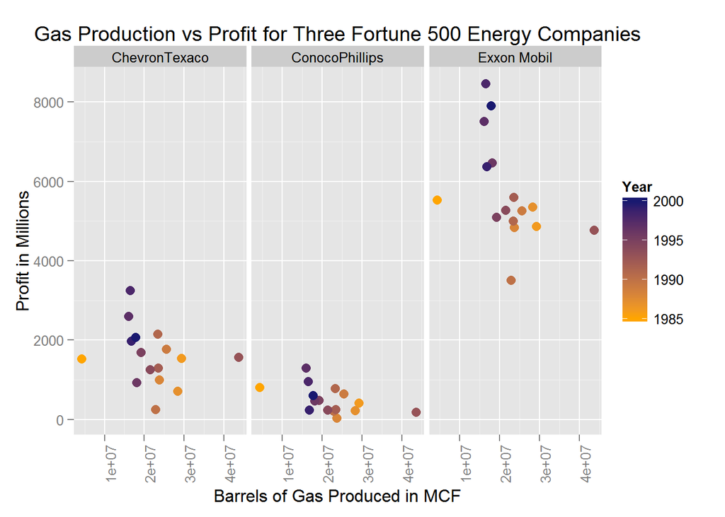

```
##
## > ggplot(Dow_Country) + coord_cartesian() + scale_x_continuous() +
## +     scale_y_continuous() + labs(title = "Dow Jones Industrial Avg vs World Popul ..." ... [TRUNCATED]
```

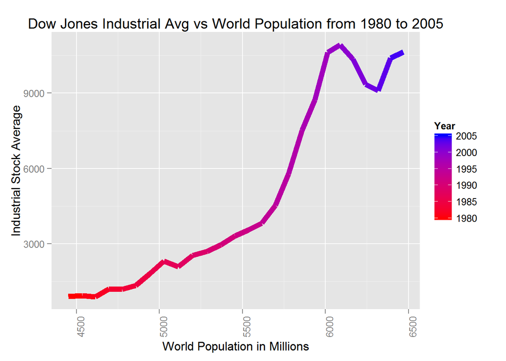

```
##
## > ggplot() + coord_cartesian() + scale_x_continuous() +
## +     scale_y_continuous() + facet_grid(~RANK, labeller = label_both) +
## +     labs(title = " ..." ... [TRUNCATED]
```

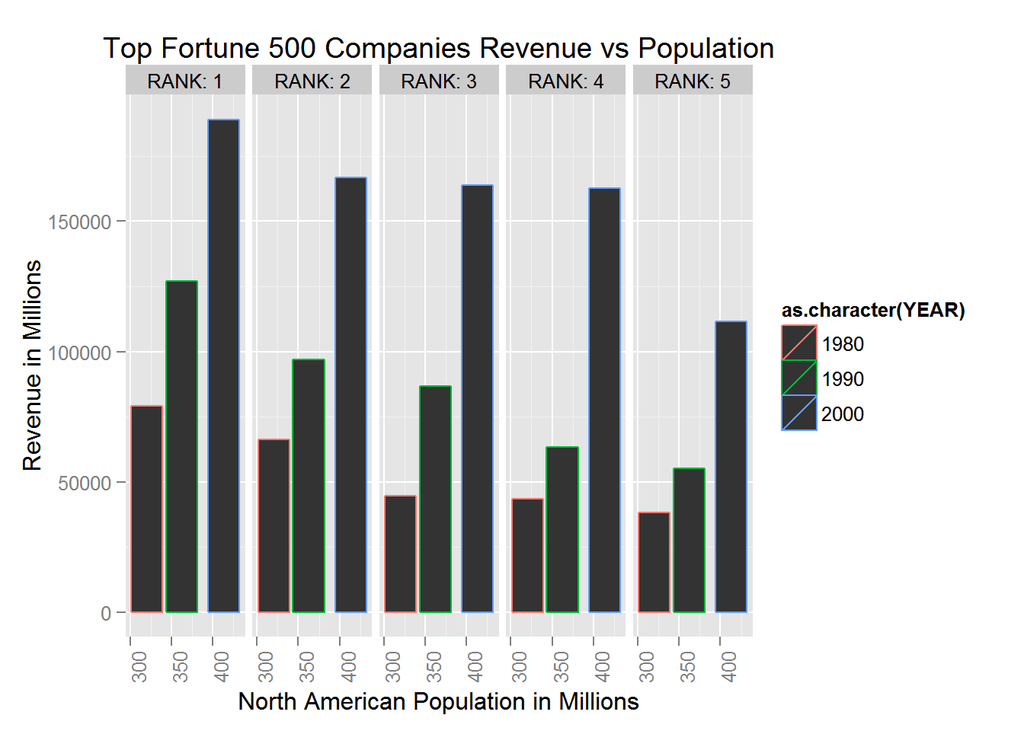